# Statistical Methods for Insurance: Compiling data for problem solving

W8.C1

## Overview of this class

- What is `tidy data`? Why do you want tidy data? Getting your data into tidy form using tidyr.
- Wrangling verbs: `filter`, `arrange`, `select`, `mutate`, `summarise`, with dplyr
- Date and time with lubridate

## Terminology

1. `Cases, records, individuals, subjects, experimental units, example, instance`: things we are collecting information about
2. `Variables, attributes, fields, features`: what we are measuring on each record/case/…/instance

Generally we think of cases being on the rows, and variables being in the columns of a table. This is a basic data structure. BUT data often is given to us in many other shapes than this. Getting into a tidy shape will allow you to efficiently use it for modeling.

## Example 1

| Inst | AvNumPubs | AvNumCits | PctCompletion |
| --- | --- | --- | --- |
| ARIZONA STATE UNIVERSITY | 0.90 | 1.57 | 31.7 |
| AUBURN UNIVERSITY | 0.79 | 0.64 | 44.4 |
| BOSTON COLLEGE | 0.51 | 1.03 | 46.8 |
| BOSTON UNIVERSITY | 0.49 | 2.66 | 34.2 |

- Cases: __________
- Variables: __________

## Example 2

| V1 | V2 | V3 | V4 | V5 | V9 | V13 | V17 | V21 | V25 | V29 | V33 | V37 | V41 | V45 | V49 | V53 | V57 | V61 | V65 | V69 | V73 | V77 | V81 | V85 | V89 | V93 | V97 | V101 | V105 | … |
| --- | --- | --- | --- | --- | --- | --- | --- | --- | --- | --- | --- | --- | --- | --- | --- | --- | --- | --- | --- | --- | --- | --- | --- | --- | --- | --- | --- | --- | --- | --- |
| ASN00086282 | 1970 | 7 | TMAX | 141 | 124 | 113 | 123 | 148 | 149 | 139 | 153 | 123 | 108 | 119 | 112 | 126 | 112 | 115 | 133 | 134 | 126 | 104 | 143 | 141 | 134 | 117 | 142 | 158 | 149 | … |
| ASN00086282 | 1970 | 7 | TMIN | 80 | 63 | 36 | 57 | 69 | 47 | 84 | 78 | 49 | 42 | 48 | 56 | 51 | 36 | 44 | 39 | 40 | 58 | 15 | 33 | 51 | 74 | 39 | 66 | 78 | 36 | … |
| ASN00086282 | 1970 | 7 | PRCP | 3 | 30 | 0 | 0 | 36 | 3 | 0 | 0 | 10 | 23 | 3 | 0 | 5 | 0 | 0 | 0 | 0 | 0 | 8 | 0 | 18 | 0 | 0 | 0 | 0 | 13 | … |
| ASN00086282 | 1970 | 8 | TMAX | 145 | 128 | 150 | 122 | 109 | 112 | 116 | 142 | 166 | 127 | 117 | 127 | 159 | 143 | 114 | 65 | 113 | 125 | 129 | 147 | 161 | 168 | 178 | 161 | 145 | 142 | … |

- Cases: __________
- Variables: __________

## Example 3

Here are the column headers …

```
#>  [1] "iso2"   "year"   "m_04"   "m_514"  "m_014"  "m_1524" "m_2534"
#>  [8] "m_3544" "m_4554" "m_5564" "m_65"   "m_u"    "f_04"   "f_514"
#> [15] "f_014"  "f_1524" "f_2534" "f_3544" "f_4554" "f_5564" "f_65"
#> [22] "f_u"
```

- Cases: __________
- Variables: __________

## Example 4

We'll commonly find these data on web sites:

| religion | <$10k | $10-20k | $20-30k | $30-40k |
| --- | --- | --- | --- | --- |
| Agnostic | 27 | 34 | 60 | 81 |
| Atheist | 12 | 27 | 37 | 52 |
| Buddhist | 27 | 21 | 30 | 34 |
| Catholic | 418 | 617 | 732 | 670 |
| Don’t know/refused | 15 | 14 | 15 | 11 |

- Cases: __________
- Variables: __________

## Example 5

10 week sensory experiment, 12 individuals assessed taste of french fries on several scales (how potato-y, buttery, grassy, rancid, paint-y do they taste?), fried in one of 3 different oils, replicated twice. First few rows:

| time | treatment | subject | rep | potato | buttery | grassy | rancid | painty |
| --- | --- | --- | --- | --- | --- | --- | --- | --- |
| 1 | 1 | 3 | 1 | 2.9 | 0.0 | 0.0 | 0.0 | 5.5 |
| 1 | 1 | 3 | 2 | 14.0 | 0.0 | 0.0 | 1.1 | 0.0 |
| 1 | 1 | 10 | 1 | 11.0 | 6.4 | 0.0 | 0.0 | 0.0 |
| 1 | 1 | 10 | 2 | 9.9 | 5.9 | 2.9 | 2.2 | 0.0 |

What do you like to know?

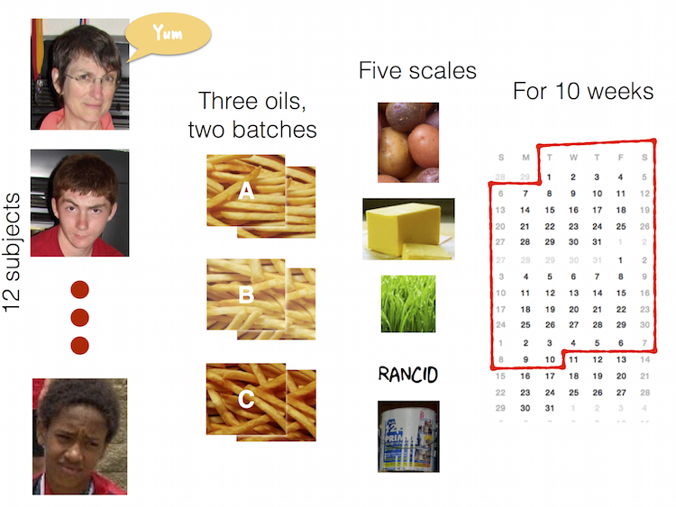

## Messy Data Patterns

There are various features of messy data that one can observe in practice. Here are some of the more commonly observed patterns.

- Column headers are values, not variable names
- Variables are stored in both rows and columns, contingency table format
- Information stored in multiple tables
- Dates in many different formats
- Not easy to analyse

## What is Tidy Data?

- Each observation forms a row
- Each variable forms a column
- Contained in a single table
- Long form makes it easier to reshape in many different ways
- Wide form is common for analysis/modeling

[figure not shown]

## Tidy vs Messy

- Tidy data facilitates analysis in many different ways, answering multiple questions, applying methods to new data or other problems
- Messy data may work for one particular problem but is not generalisable

## Tidy Verbs

- `gather`: specify the `keys` (identifiers) and the `values` (measures) to make long form (used to be called melting)
- `spread`: variables in columns (used to be called casting)
- nest/unnest: working with lists
- separate/unite: split and combine columns

## French fries example

|  | time | treatment | subject | rep | potato | buttery | grassy | rancid | painty |
| --- | --- | --- | --- | --- | --- | --- | --- | --- | --- |
| 61 | 1 | 1 | 3 | 1 | 2.9 | 0.0 | 0.0 | 0.0 | 5.5 |
| 25 | 1 | 1 | 3 | 2 | 14.0 | 0.0 | 0.0 | 1.1 | 0.0 |
| 62 | 1 | 1 | 10 | 1 | 11.0 | 6.4 | 0.0 | 0.0 | 0.0 |
| 26 | 1 | 1 | 10 | 2 | 9.9 | 5.9 | 2.9 | 2.2 | 0.0 |
| 63 | 1 | 1 | 15 | 1 | 1.2 | 0.1 | 0.0 | 1.1 | 5.1 |
| 27 | 1 | 1 | 15 | 2 | 8.8 | 3.0 | 3.6 | 1.5 | 2.3 |

## This format is not ideal for data analysis

What code would be needed to plot each of the ratings over time as a different color?

```
library(ggplot2)
french_sub <- french_fries[french_fries$time == 10,]
ggplot(data = french_sub) +
  geom_boxplot(aes(x="1_potato", y=potato), fill = I("red")) +
 geom_boxplot(aes(x = "2_buttery", y = buttery), fill = I("orange")) +
 geom_boxplot(aes(x = "3_grassy", y = grassy), fill = I("yellow")) +
 geom_boxplot(aes(x = "4_rancid", y = rancid), fill = I("green")) +
 geom_boxplot(aes(x = "5_painty", y = painty), fill = I("blue")) +
    xlab("variable") + ylab("rating")
```

## The plot

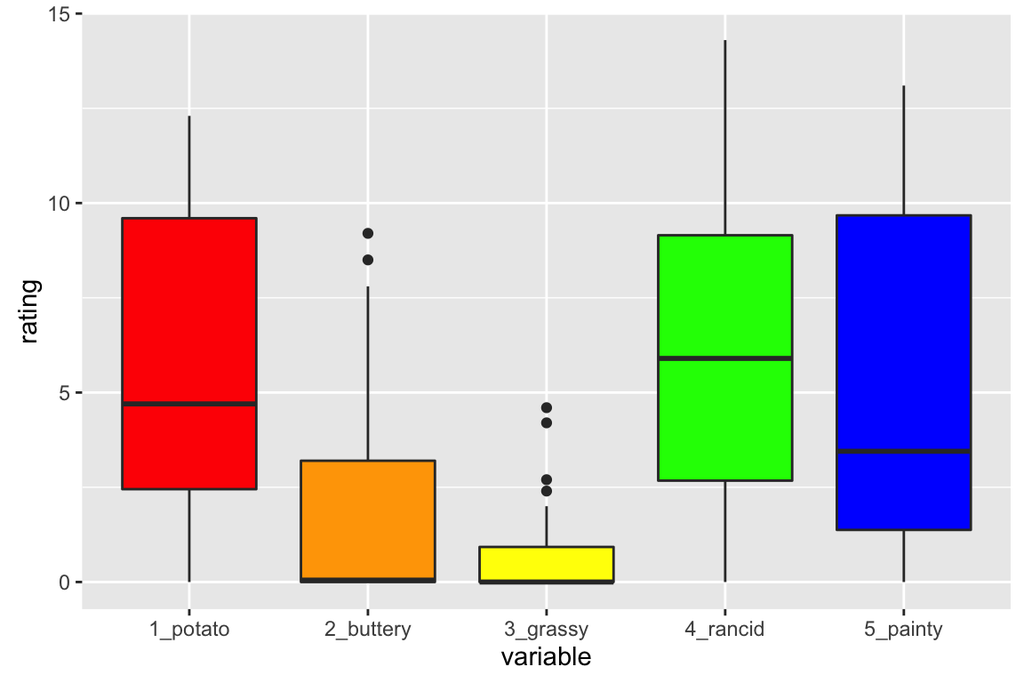

## Wide to long

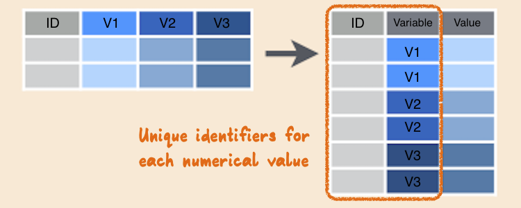

## Gathering

- When gathering, you need to specify the **keys** (identifiers) and the **values** (measures).
- Keys/Identifiers:
  - Identify a record (must be unique)
  - Example: Indices on an random variable
  - Fixed by design of experiment (known in advance)
  - May be single or composite (may have one or more variables)
- Values/Measures:
  - Collected during the experiment (not known in advance)
  - Usually numeric quantities

## Gathering the French Fries Data

```
ff_long <- gather(french_fries, key = variable,
  value = rating, potato:painty)

head(ff_long)
```

```
#>   time treatment subject rep variable rating
#> 1    1         1       3   1   potato    2.9
#> 2    1         1       3   2   potato   14.0
#> 3    1         1      10   1   potato   11.0
#> 4    1         1      10   2   potato    9.9
#> 5    1         1      15   1   potato    1.2
#> 6    1         1      15   2   potato    8.8
```

## Let's re-write the code for our Plot

```
ff_long_sub <- ff_long[
  french_fries_long$time == 10,]

ggplot(data = ff_long_sub,
  aes(x=variable, y=rating,  fill = variable)) +
   geom_boxplot()
```

## And plot it

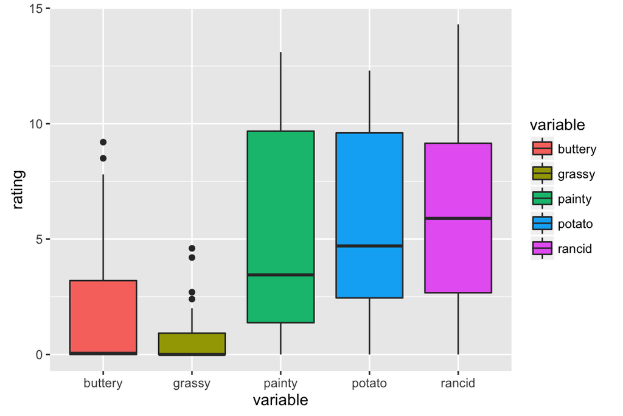

## Long to Wide

In certain applications, we may wish to take a long dataset and convert it to a wide dataset (Perhaps displaying in a table).

```
#>   time treatment subject rep variable rating
#> 1    1         1       3   1   potato    2.9
#> 2    1         1       3   2   potato   14.0
#> 3    1         1      10   1   potato   11.0
#> 4    1         1      10   2   potato    9.9
#> 5    1         1      15   1   potato    1.2
#> 6    1         1      15   2   potato    8.8
```

## Spread

We use the **spread** function from tidyr to do this:

```
ff_wide <- spread(ff_long,
  key = variable, value = rating)
head(ff_wide)
```

```
#>   time treatment subject rep buttery grassy painty potato rancid
#> 1    1         1       3   1     0.0    0.0    5.5    2.9    0.0
#> 2    1         1       3   2     0.0    0.0    0.0   14.0    1.1
#> 3    1         1      10   1     6.4    0.0    0.0   11.0    0.0
#> 4    1         1      10   2     5.9    2.9    0.0    9.9    2.2
#> 5    1         1      15   1     0.1    0.0    5.1    1.2    1.1
#> 6    1         1      15   2     3.0    3.6    2.3    8.8    1.5
```

## The Split-Apply-Combine Approach

- *Split* a dataset into many smaller sub-datasets
- *Apply* some function to each sub-dataset to compute a result
- *Combine* the results of the function calls into a one dataset

## The Split-Apply-Combine Approach


## Split-Apply-Combine in dplyr

```
library(dplyr)
ff_summary <- group_by(ff_long, variable) %>% # SPLIT
  summarise(
      m = mean(rating, na.rm = TRUE),
      s=sd(rating, na.rm=TRUE)) # APPLY + COMBINE
ff_summary
```

```
#> # A tibble: 5 x 3
#>   variable         m        s
#>      <chr>     <dbl>    <dbl>
#> 1  buttery 1.8236994 2.409758
#> 2   grassy 0.6641727 1.320574
#> 3   painty 2.5217579 3.393717
#> 4   potato 6.9525180 3.584403
#> 5   rancid 3.8522302 3.781815
```

## Pipes

- Pipes historically enable data analysis pipelines
- Pipes allow the code to be **read** like a sequence of operations
- dplyr allows us to chain together these data analysis tasks using the `%>%` (pipe) operator
- `x %>% f(y)` is shorthand for `f(x, y)`
- Example:

```r
student2012.sub <- readRDS("../data/student_sub.rds")
student2012.sub %>%
  group_by(CNT) %>%
  tally()
```

```
#> # A tibble: 43 x 2
#>      CNT     n
#>    <chr> <int>
#> 1    ARE 11500
#> 2    AUS 14481
#> 3    AUT  4755
#> 4    BEL  8597
#> 5    BGR  5282
#> 6    BRA  5506
#> 7    CAN 21544
#> 8    CHL  6856
#> 9    COL  9073
#> 10   CZE  5327
#> # ... with 33 more rows
```

## dplyr verbs

There are five primary dplyr `verbs`, representing distinct data analysis tasks:

- `Filter`: Remove the rows of a data frame, producing subsets
- `Arrange`: Reorder the rows of a data frame
- `Select`: Select particular columns of a data frame
- `Mutate`: Add new columns that are functions of existing columns
- `Summarise`: Create collapsed summaries of a data frame

## Filter

```
french_fries %>%
    filter(subject == 3, time == 1)
```

```
#>   time treatment subject rep potato buttery grassy rancid painty
#> 1    1         1       3   1    2.9     0.0    0.0    0.0    5.5
#> 2    1         1       3   2   14.0     0.0    0.0    1.1    0.0
#> 3    1         2       3   1   13.9     0.0    0.0    3.9    0.0
#> 4    1         2       3   2   13.4     0.1    0.0    1.5    0.0
#> 5    1         3       3   1   14.1     0.0    0.0    1.1    0.0
#> 6    1         3       3   2    9.5     0.0    0.6    2.8    0.0
```

## Arrange

```
french_fries %>%
    arrange(desc(rancid)) %>%
    head
```

```
#>   time treatment subject rep potato buttery grassy rancid painty
#> 1    9         2      51   1    7.3     2.3      0   14.9    0.1
#> 2   10         1      86   2    0.7     0.0      0   14.3   13.1
#> 3    5         2      63   1    4.4     0.0      0   13.8    0.6
#> 4    9         2      63   1    1.8     0.0      0   13.7   12.3
#> 5    5         2      19   2    5.5     4.7      0   13.4    4.6
#> 6    4         3      63   1    5.6     0.0      0   13.3    4.4
```

## Select

```
french_fries %>%
    select(time, treatment, subject, rep, potato) %>%
    head
```

```
#>    time treatment subject rep potato
#> 61    1         1       3   1    2.9
#> 25    1         1       3   2   14.0
#> 62    1         1      10   1   11.0
#> 26    1         1      10   2    9.9
#> 63    1         1      15   1    1.2
#> 27    1         1      15   2    8.8
```

## Mutate

```
french_fries %>%
    mutate(yucky = grassy+rancid+painty) %>%
  head
```

```
#>   time treatment subject rep potato buttery grassy rancid painty yucky
#> 1    1         1       3   1    2.9     0.0    0.0    0.0    5.5   5.5
#> 2    1         1       3   2   14.0     0.0    0.0    1.1    0.0   1.1
#> 3    1         1      10   1   11.0     6.4    0.0    0.0    0.0   0.0
#> 4    1         1      10   2    9.9     5.9    2.9    2.2    0.0   5.1
#> 5    1         1      15   1    1.2     0.1    0.0    1.1    5.1   6.2
#> 6    1         1      15   2    8.8     3.0    3.6    1.5    2.3   7.4
```

## Summarise

```
french_fries %>%
    group_by(time, treatment) %>%
    summarise(mean_rancid = mean(rancid),
    sd_rancid = sd(rancid))
```

```
#> Source: local data frame [30 x 4]
#> Groups: time [?]
#>
#>      time treatment mean_rancid sd_rancid
#>    <fctr>    <fctr>       <dbl>     <dbl>
#> 1       1         1    2.758333  3.212870
#> 2       1         2    1.716667  2.714801
#> 3       1         3    2.600000  3.202037
#> 4       2         1    3.900000  4.374730
#> 5       2         2    2.141667  3.117540
#> 6       2         3    2.495833  3.378767
#> 7       3         1    4.650000  3.933358
#> 8       3         2    2.895833  3.773532
#> 9       3         3    3.600000  3.592867
#> 10      4         1    2.079167  2.394737
#> # ... with 20 more rows
```

## Dates and Times

- Dates are deceptively hard to work with
- 02/05/2012. Is it February 5th, or May 2nd?
- Time zones
- Different starting times of stock markets, airplane departure and arrival

## Basic Lubridate Use

```r
library(lubridate)

now()
```

```
#> [1] "2016-09-14 19:52:52 AEST"
```

```r
now(tz = "America/Chicago")
```

```
#> [1] "2016-09-14 04:52:52 CDT"
```

```r
today()
```

```
#> [1] "2016-09-14"
```

```r
now() + hours(4)
```

```
#> [1] "2016-09-14 23:52:52 AEST"
```

```r
today() - days(2)
```

```
#> [1] "2016-09-12"
```

```r
ymd("2013-05-14")
```

```
#> [1] "2013-05-14"
```

```r
mdy("05/14/2013")
```

```
#> [1] "2013-05-14"
```

```r
dmy("14052013")
```

```
#> [1] "2013-05-14"
```

## Dates example: Oscars date of birth

```r
oscars <- read_csv("../data/oscars.csv")
oscars <- oscars %>% mutate(DOB = mdy(DOB))
head(oscars$DOB)
```

```
#> [1] "1895-09-30" "1884-07-23" "1894-04-23" "2006-10-06" "1886-02-02"
#> [6] "1892-04-08"
```

```r
summary(oscars$DOB)
```

```
#>         Min.      1st Qu.       Median         Mean      3rd Qu.
#> "1868-04-10" "1934-09-18" "1957-06-23" "1962-05-21" "2008-04-05"
#>         Max.
#> "2029-12-13"
```

## Calculating on dates

- You should never ask a woman her age, but … really!

```r
oscars <- oscars %>% mutate(year=year(DOB))
summary(oscars$year)
```

```
#>    Min. 1st Qu.  Median    Mean 3rd Qu.    Max.
#>    1868    1934    1957    1962    2008    2029
```

```r
oscars %>% filter(year == "2029") %>%
  select(Name, Sex, DOB)
```

```
#> # A tibble: 4 x 3
#>                  Name    Sex        DOB
#>                 <chr>  <chr>     <date>
#> 1      Audrey Hepburn Female 2029-05-04
#> 2         Grace Kelly Female 2029-11-12
#> 3       Miyoshi Umeki Female 2029-04-03
#> 4 Christopher Plummer   Male 2029-12-13
```

## Months

```r
oscars <- oscars %>% mutate(month=month(DOB, label = TRUE, abbr = TRUE))
table(oscars$month)
```

```
#>
#> Jan Feb Mar Apr May Jun Jul Aug Sep Oct Nov Dec
#>  32  35  37  53  35  27  37  33  31  31  30  42
```

## Now plot it

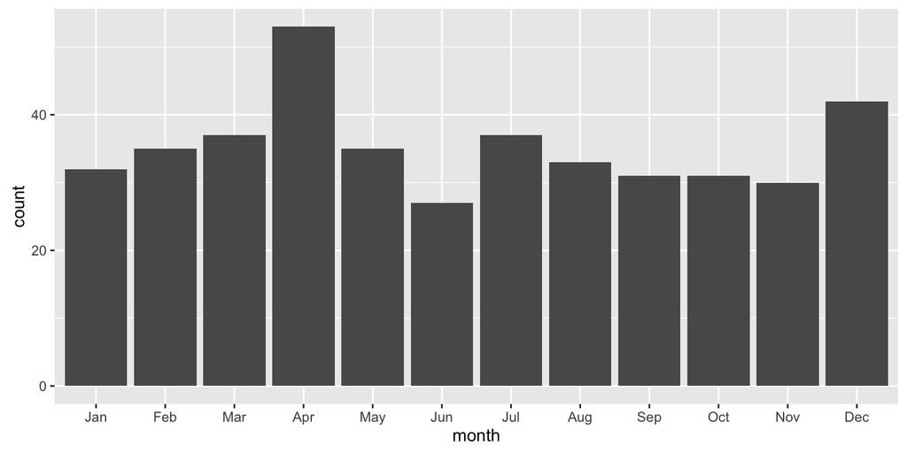

```r
ggplot(data=oscars, aes(month)) + geom_bar()
```

## Should you be born in April?

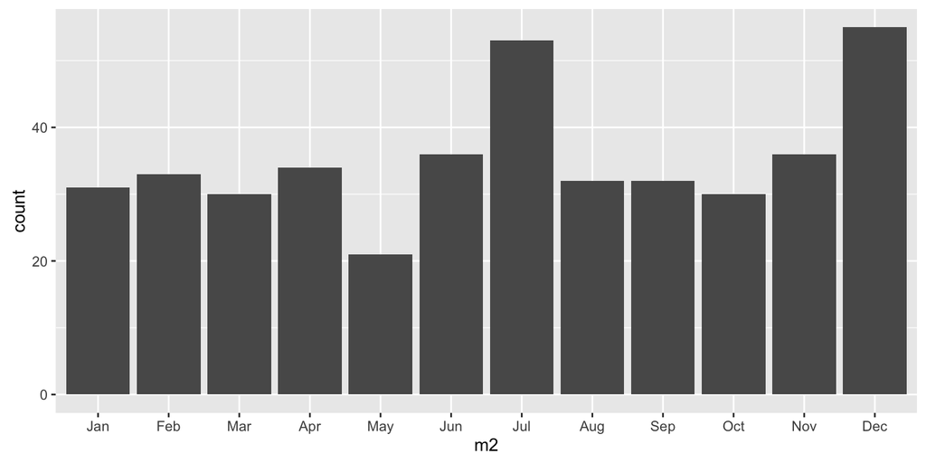

```r
df <- data.frame(m=sample(1:12, 423, replace=TRUE))
df$m2 <- factor(df$m, levels=1:12,
  labels=month.abb)
ggplot(data=df, aes(x=m2)) + geom_bar()
```

## Resources

- [Tidy data](http://vita.had.co.nz/papers/tidy-data.pdf)
- [Split-apply-combine](http://vita.had.co.nz/papers/plyr.pdf)
- [RStudio cheat sheets](https://www.rstudio.com/resources/cheatsheets/)
- [Working with dates and times](https://www.jstatsoft.org/article/view/v040i03/v40i03.pdf)
- [R for Data Science](http://r4ds.had.co.nz)

## Share and share alike

This work is licensed under the Creative Commons Attribution-Noncommercial 3.0 United States License. To view a copy of this license, visit http://creativecommons.org/licenses/by-nc/ 3.0/us/ or send a letter to Creative Commons, 171 Second Street, Suite 300, San Francisco, California, 94105, USA.